# Application to the interpretation of the GNPS components

Alexis Delabriere

25 Oktober 2019

#### Package

mineMS2 0.9.2

# 1 Introduction

This vignette describes the use of the *mineMS2* software coupled to the GNPS MS/MS molecular networking methodology (Watrous et al. 2012). In this example, the molecular network has been precomputed on the GNPS website and extracted in the *.graphML* format (file *ex_gnps_network.graphml* inside the *dataset* subdirectory of the *mineMS2* installation folder). We strongly recommend to compute the patterns and the GNPS network on the same .mgf file to avoir matching issues.

# 2 Pre-requisites

## 2.1 Dataset

Secondary metabolites of *Penicillium verrucosum* have been studied by Data Independent Acquisition (Hautbergue et al. 2017). The subset of 45 MS/MS spectra provided in the package corresponds to the spectra at the HCD20 energy with an associated MS signal in positive mode (as detected by the MZmine software, Pluskal et al. (2010)).

## 2.2 Initialization

The initialization loads the required packages and extracts the data paths.

```r
library(mineMS2)
```

```r
path_demo <- system.file("dataset",package="mineMS2")
path_network <- file.path(path_demo,"ex_gnps_network.graphml")
path_mgf <- file.path(path_demo,"ex_mgf.mgf")
path_supp_info <- file.path(path_demo,"ex_supp_infos.csv")
```

## 2.3 Patterns mining

The pattern mining step is detailed in the mineMS2 main vignette. Briefly, i) all mass losses within the spectra are computed, ii) a graph representation of each fragmentation spectrum using the losses as edges is built (Directed Acyclic Graph, DAG), and iii) the DAGs are mined to extract frequent patterns.

```r
supp_infos <- read.table(path_supp_info,header=TRUE,sep=";")

### Sepctra are read and thresholded
m2l <- ms2Lib(path_mgf,suppInfos = supp_infos, intThreshold = 3000)
```

```
## .............................................
```

```r
### An ID is added to each spectra
infos <- getInfo(m2l,"S")
ids <- paste(paste("MZ",infos[,"mz"],sep=""),paste("RT",infos[,"rt"],sep=""),sep="_")
m2l <- setIds(m2l,ids)

### DAGs are created
m2l <- discretizeMassLosses(m2l,dmz = 0.008,ppm=8,heteroAtoms=FALSE,maxFrags=15)

### Patterns are detected
m2l <- mineClosedSubgraphs(m2l,sizeMin=1,count=2)
```

In the rest of this vignette, we show how these patterns can be used to interpret the components of molecular networks generated by GNPS.

# 3 Coupling mineMS2 to GNPS

## 3.1 Loading the GNPS network

The GNPS network may be read using the *igraph* package:

```r
library(igraph)

net_gnps <- read_graph(path_network, "graphml")
```

Since self-edges (i.e. single loops) are automatically added by GNPS to single nodes, we use the *simplify* function form the *igraph* package to remove these edges.

```r
net_gnps <- simplify(net_gnps,remove.multiple = FALSE,edge.attr.comb = "ignore")
```

An overview of the GNPS network after this processing is shown below (as visualized with the cytoscape software (Shannon et al. 2003)):

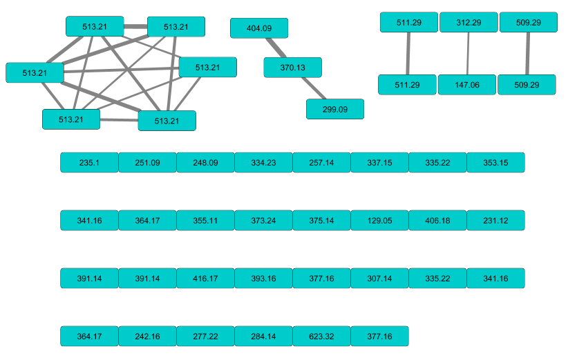

Within this network, the *mineMS2* patterns are useful to interpret the connected components (subgraphs in which any two nodes are connected by a path), the cliques (subgraphs in which any all pairs of nodes are connected), as well as the strong similarities between nodes, as described below.

## 3.2 Extracting components from a molecular network

The connected components and the cliques may be extracted using the *findGNPSComponents* function. The important parameters of this function are i) the *minSize* parameter, which indicates the minimum size of the detected cliques, and ii) the *pairThreshold* threshold, which indicates a similarity threshold for which an explanation of a single edge is generated.

```r
components <- findGNPSComponents(net_gnps,minSize=3,pairThreshold = 0.9)
```

A list of graph components is generated which may be explained by a pattern.

## 3.3 Finding patterns explaining components

```r
patterns <- findPatternsExplainingComponents(m2l,components,metric=c("recall","precision","size"))
```

The returned list includes all the metric values for the given patterns, as well as the id of the explaining patterns.

```r
patterns[[1]]
```

```
##    id        f1 precision recall miss size
## P5 P5 0.4347826 0.2777778      1    0    2
```

These patterns can be observed using the *plot* and *plotOccurences* functions, which are wrapped inside the *plotPatterns* function for convenience. This function may be used to generate a pdf output.

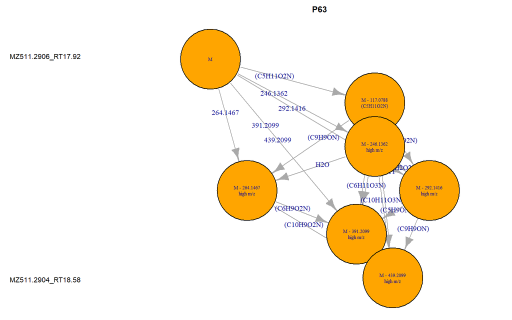

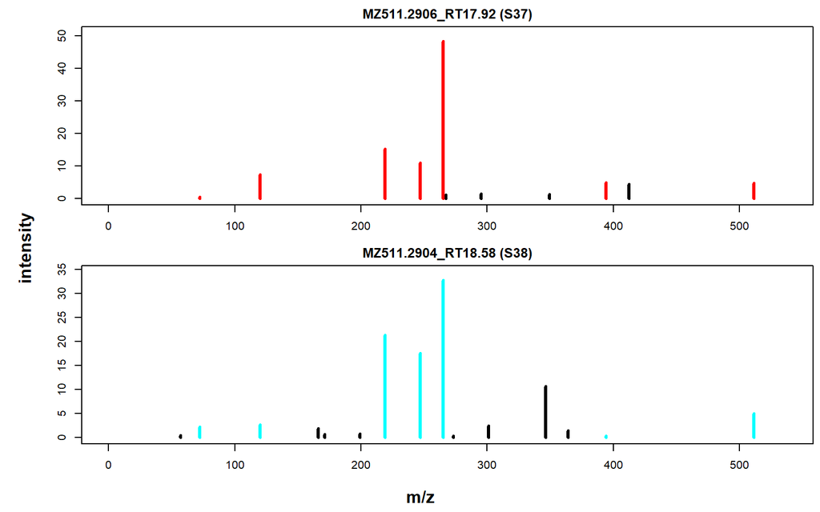

```r
### Here a single id is selected for clarity.
plotPatterns(m2l,patterns[[4]][,"id"],components = components[4])
```

The network may be directly annotated using the *annotateNetwork* function.

```r
annotated_net <- annotateNetwork(components,net_gnps,patterns)
```

The annotated network can be exported using the *write_graph* function from the *igraph* package.

```r
write_graph(graph = annotated_net,format = "graphml",file = "ex_annotated_gnps_network.graphml")
```

This network can be visualized in Cytoscape (note that the GraphML format is supported by Cytoscape 3: select ‘File > Import > Network from file’; with Cytoscape 2, the GraphMLReader plugin is needed):

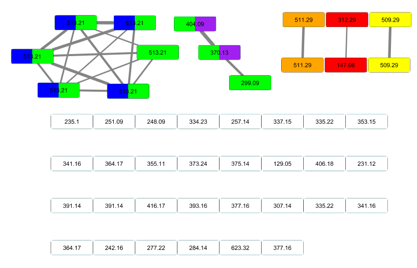

To visualize the colors, the *enhancedGraphics* App from Cytoscape is required (‘Apps > Install Apps > Search: enhanced Graphics’). Then, in the *Style* tab from the *Control Panel*, select for the *Image/Chart 1* the *Column: colorComponents* and the *Mapping Type: Passthrough Mapping*. Each component is assigned a color: nodes with several colors belong to several components.

## 3.4 Interpreting the components in terms of fragmentation patterns

We can now interpret the molecular network in terms of fragmentation patterns.

First, we investigate the pattern explaining the biggest component (which consists of isomeric compounds with m/z $513.21$), which is P5. We can plot this pattern using the *plotPatterns* method:

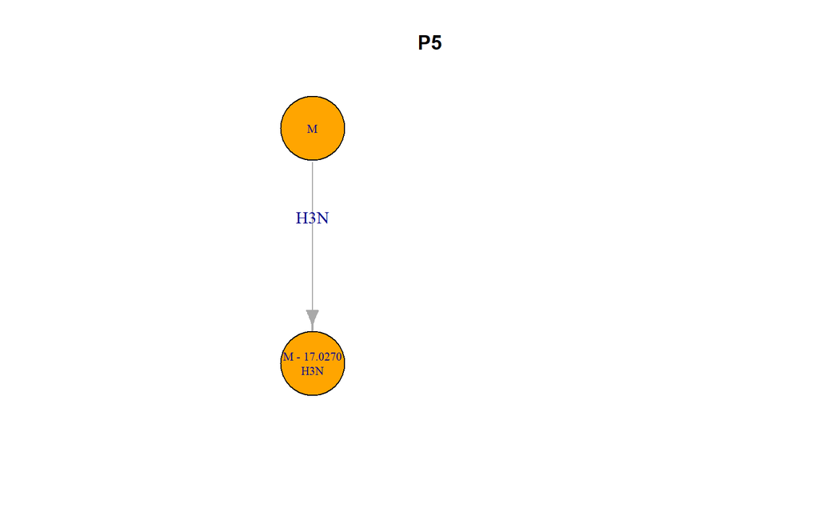

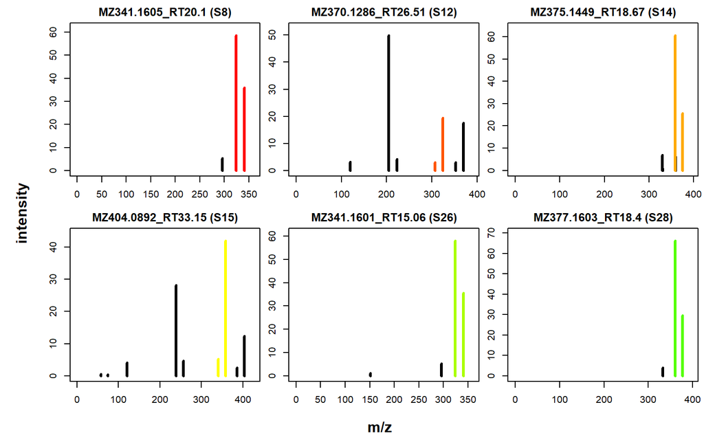

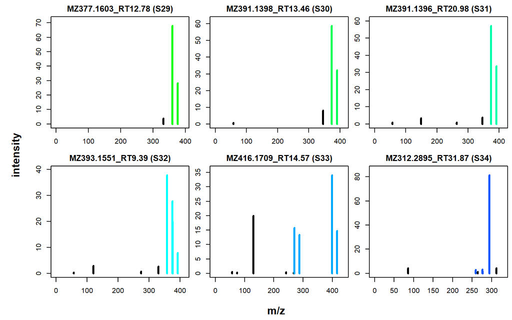

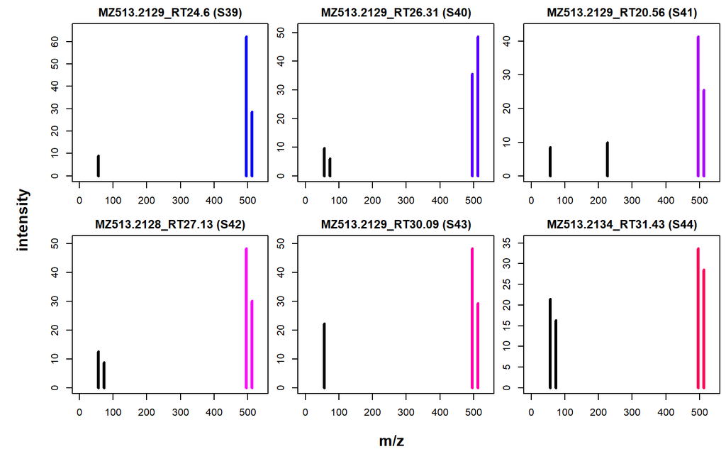

```r
id_pat <- patterns[[1]][,"id"]
plotPatterns(m2l,id_pat)
```

We see that the 6 fragmentation spectra share an $NH_3$ loss. This single $NH_3$ loss is also observed in many different spectra, and is representative of an amine loss.

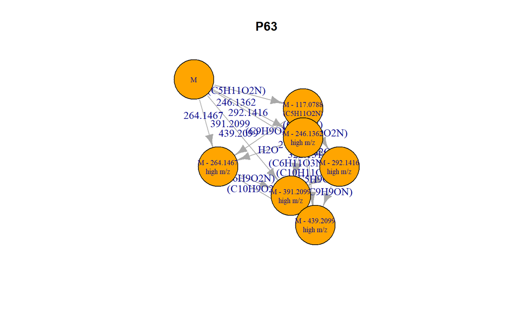

```r
id_pat <- patterns[[4]][,"id"]
plot(m2l,id_pat)
```

This pattern includes a loss of $147.068$ with the following information (*findMz* and *getInfo* functions):

```r
L147 <- findMz(m2l,147.068,ppm=8,dmz=0.005,type="L")
getInfo(m2l,L147)
```

```
##     lab       mz    mzmin    mzmax count
## L77  77 147.0682 147.0628 147.0735    12
##                                    formula
## L77 C4H9O3N3|C9H9ON|H5ON9|C5H9O4N|C2H13O6N
```

We see that one possible formula for the loss is $C_9H_9NO$, which corresponds to phenylalanine.

## 3.5 Beyond molecular networks: discovering new similarities between spectra

The patterns also help discovering new similarities between spectra. Getting back to the $147.068$ loss above, it is now possible to look for this loss in other patterns using the *select* function:

```r
ids_phenylalanine <- select(m2l,L147,"P")
ids_phenylalanine
```

```
## $L77
## [1] "P11" "P15" "P16" "P63" "P68" "P69"
```

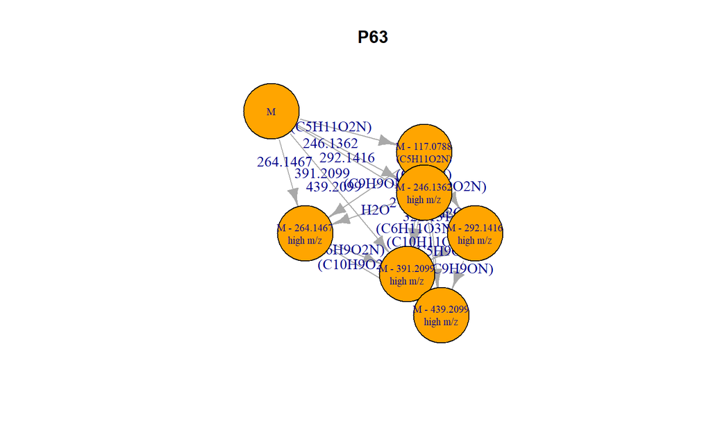

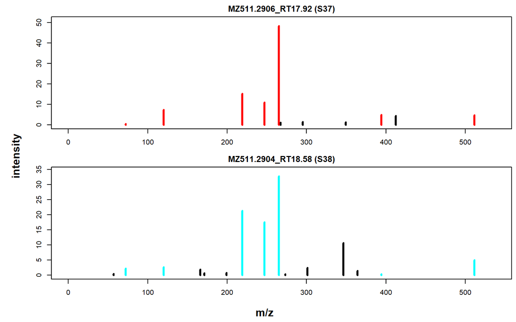

```r
plotPatterns(m2l,ids_phenylalanine[[1]][4])
```

# Bibliography

Hautbergue, Thaïs, Olivier Puel, Souria Tadrist, Lauriane Meneghetti, Michel Péan, Marcel Delaforge, Laurent Debrauwer, Isabelle P. Oswald, and Emilien L. Jamin. 2017. “Evidencing 98 Secondary Metabolites of Penicillium Verrucosum Using Substrate Isotopic Labeling and High-Resolution Mass Spectrometry.” *Journal of Chromatography B* 1071: 29–43. https://doi.org/https://doi.org/10.1016/j.jchromb.2017.03.011.

Pluskal, Tomas, Sandra Castillo, Alejandro Villar-Briones, and Matej Oresic. 2010. “MZmine 2: Modular Framework for Processing, Visualizing, and Analyzing Mass Spectrometry- Based Molecular Profile Data.” *BMC Bioinformatics*. https://doi.org/10.1186/1471-2105-11-395.

Shannon, Paul, Andrew Markiel, Owen Ozier, Nitin S Baliga, Jonathan T Wang, Daniel Ramage, Nada Amin, Benno Schwikowski, and Trey Ideker. 2003. “Cytoscape: A Software Environment for Integrated Models of Biomolecular Interaction Networks.” *Genome Research* 13 (11): 2498–2504. https://www.ncbi.nlm.nih.gov/pubmed/14597658.

Watrous, Jeramie, Patrick Roach, Theodore Alexandrov, Brandi S. Heath, Jane Y. Yang, Roland D. Kersten, Menno van der Voort, et al. 2012. “Mass Spectral Molecular Networking of Living Microbial Colonies.” *Proceedings of the National Academy of Sciences* 109 (26): E1743–E1752. https://doi.org/10.1073/pnas.1203689109.